# Bellabeat Case Study

Marcus Madison

2022-05-11

#About Bellabeat

Bellabeat is a high tech manufacturer of health based products for women, and even though small they have been quite successful. Urška Sršen, co-founder and Chief Creative Officer of Bellabeat, knows the company has potential to be a major player in the global smart device market and believes that by analyzing smart device data new growth potential can be found.

##Main Questions

1.What are some trends in smart device usage?

2.How could these trends apply to Bellabeat customers?

3.How could these trends help influence Bellabeat marketing strategy?

##Business Task

Analyze data on smart device usage on non-Bellabeat smart devices, then use those insights to provide recommendations for Bellabeat marketing strategy improvement.

#Data Preparation

Installed and Loaded packages that would be necesary for the preparation and analysis of the data.

Then imported the data into R Studio, which had already been cleaned and validated in in Sheets prior

```r
sleepDay <- read_csv(" sleepDay.csv")
dailyActivity <- read_csv("daily_activity.csv")
dailyCalories <- read_csv("dailyCalories.csv")
dailyIntensities <- read_csv("dailyIntensities.csv")
dailySteps <- read_csv("dailySteps.csv")
heartrate_seconds_merged <- read_csv("heartrate_seconds_merged.csv")
hourlyCalories <- read_csv("hourlyCalories.csv")
hourlyIntensities <- read_csv("hourlyIntensities.csv")
weightLogInfo <- read_csv("weightLogInfo.csv")
```

To make sure they were imported correctly I used the head fucntion to take a look at the csv files as dataframes

```
## # A tibble: 6 × 3
##           Id ActivityHour          Calories
##        <dbl> <chr>                    <dbl>
## 1 1503960366 4/12/2016 12:00:00 AM       81
## 2 1503960366 4/12/2016 1:00:00 AM        61
## 3 1503960366 4/12/2016 2:00:00 AM        59
## 4 1503960366 4/12/2016 3:00:00 AM        47
## 5 1503960366 4/12/2016 4:00:00 AM        48
## 6 1503960366 4/12/2016 5:00:00 AM        48
```

```
## # A tibble: 6 × 4
##           Id ActivityHour          TotalIntensity AverageIntensity
##        <dbl> <chr>                          <dbl>            <dbl>
## 1 1503960366 4/12/2016 12:00:00 AM             20            0.333
## 2 1503960366 4/12/2016 1:00:00 AM               8            0.133
## 3 1503960366 4/12/2016 2:00:00 AM               7            0.117
## 4 1503960366 4/12/2016 3:00:00 AM               0            0
## 5 1503960366 4/12/2016 4:00:00 AM               0            0
## 6 1503960366 4/12/2016 5:00:00 AM               0            0
```

```
## # A tibble: 6 × 15
##        Id ActivityDate TotalSteps TotalDistance TrackerDistance LoggedActivitie…
##     <dbl> <chr>             <dbl>         <dbl>           <dbl>            <dbl>
## 1  1.50e9 4/12/2016         13162          8.5             8.5                 0
## 2  1.50e9 4/13/2016         10735          6.97            6.97                0
## 3  1.50e9 4/14/2016         10460          6.74            6.74                0
## 4  1.50e9 4/15/2016          9762          6.28            6.28                0
## 5  1.50e9 4/16/2016         12669          8.16            8.16                0
## 6  1.50e9 4/17/2016          9705          6.48            6.48                0
## # … with 9 more variables: VeryActiveDistance <dbl>,
## #   ModeratelyActiveDistance <dbl>, LightActiveDistance <dbl>,
## #   SedentaryActiveDistance <dbl>, VeryActiveMinutes <dbl>,
## #   FairlyActiveMinutes <dbl>, LightlyActiveMinutes <dbl>,
## #   SedentaryMinutes <dbl>, Calories <dbl>
```

```
## # A tibble: 6 × 3
##           Id ActivityDay Calories
##        <dbl> <chr>          <dbl>
## 1 1503960366 4/12/2016       1985
## 2 1503960366 4/13/2016       1797
## 3 1503960366 4/14/2016       1776
## 4 1503960366 4/15/2016       1745
## 5 1503960366 4/16/2016       1863
## 6 1503960366 4/17/2016       1728
```

```
## # A tibble: 6 × 10
##           Id ActivityDay SedentaryMinutes LightlyActiveMinutes FairlyActiveMinu…
##        <dbl> <chr>                  <dbl>                <dbl>             <dbl>
## 1 1503960366 4/12/2016                728                  328                13
## 2 1503960366 4/13/2016                776                  217                19
## 3 1503960366 4/14/2016               1218                  181                11
## 4 1503960366 4/15/2016                726                  209                34
## 5 1503960366 4/16/2016                773                  221                10
## 6 1503960366 4/17/2016                539                  164                20
## # … with 5 more variables: VeryActiveMinutes <dbl>,
## #   SedentaryActiveDistance <dbl>, LightActiveDistance <dbl>,
## #   ModeratelyActiveDistance <dbl>, VeryActiveDistance <dbl>
```

```
## # A tibble: 6 × 3
##           Id ActivityDay StepTotal
##        <dbl> <chr>           <dbl>
## 1 1503960366 4/12/2016       13162
## 2 1503960366 4/13/2016       10735
## 3 1503960366 4/14/2016       10460
## 4 1503960366 4/15/2016        9762
## 5 1503960366 4/16/2016       12669
## 6 1503960366 4/17/2016        9705
```

```
## # A tibble: 6 × 5
##           Id SleepDay           TotalSleepRecor… TotalMinutesAsl… TotalTimeInBed
##        <dbl> <chr>                         <dbl>            <dbl>          <dbl>
## 1 1503960366 4/12/2016 12:00:0…                1              327            346
## 2 1503960366 4/13/2016 12:00:0…                2              384            407
## 3 1503960366 4/15/2016 12:00:0…                1              412            442
## 4 1503960366 4/16/2016 12:00:0…                2              340            367
## 5 1503960366 4/17/2016 12:00:0…                1              700            712
## 6 1503960366 4/19/2016 12:00:0…                1              304            320
```

```
## # A tibble: 6 × 3
##           Id Time                 Value
##        <dbl> <chr>                <dbl>
## 1 2022484408 4/12/2016 7:21:00 AM    97
## 2 2022484408 4/12/2016 7:21:05 AM   102
## 3 2022484408 4/12/2016 7:21:10 AM   105
## 4 2022484408 4/12/2016 7:21:20 AM   103
## 5 2022484408 4/12/2016 7:21:25 AM   101
## 6 2022484408 4/12/2016 7:22:05 AM    95
```

```
## # A tibble: 6 × 8
##           Id Date       WeightKg WeightPounds   Fat   BMI IsManualReport   LogId
##        <dbl> <chr>         <dbl>        <dbl> <dbl> <dbl> <lgl>            <dbl>
## 1 1503960366 5/2/2016 …     52.6         116.    22  22.6 TRUE           1.46e12
## 2 1503960366 5/3/2016 …     52.6         116.    NA  22.6 TRUE           1.46e12
## 3 1927972279 4/13/2016…    134.          294.    NA  47.5 FALSE          1.46e12
## 4 2873212765 4/21/2016…     56.7         125.    NA  21.5 TRUE           1.46e12
## 5 2873212765 5/12/2016…     57.3         126.    NA  21.7 TRUE           1.46e12
## 6 4319703577 4/17/2016…     72.4         160.    25  27.5 TRUE           1.46e12
```

After importing the data, I noticed that the data type for the date needed to be updated for the dataframes, using lubridate I updated the data frames.

Now that the dates are in the correct format, I had to separate the date columns in certain data frames that contained both the date and time in a single column. This was done using the separate function.

```r
heartrate_seconds_merged<-separate(heartrate_seconds_merged,Time,c("Date","Time"),sep = " ")
weightLogInfo<-separate(weightLogInfo,Date,c("Date","Time"),sep = " ")
hourlyCalories<-separate(hourlyCalories,ActivityHour,c("Date","Time"),sep = " ")
hourlyIntensities<-separate(hourlyIntensities,ActivityHour,c("Date","Time"),sep = " ")
```

Next I check the sample size of the data sets I am choosing to analyze, usually a sample size of over 25 is reliable enough to analyze due to the variety of subjects.

```r
n_distinct(dailyActivity$Id)
```

```
## [1] 33
```

```r
n_distinct(heartrate_seconds_merged$Id)
```

```
## [1] 14
```

```r
n_distinct(weightLogInfo$Id)
```

```
## [1] 8
```

```r
n_distinct(hourlyIntensities$Id)
```

```
## [1] 33
```

```r
n_distinct(hourlyCalories$Id)
```

```
## [1] 33
```

```r
n_distinct(dailySteps$Id)
```

```
## [1] 33
```

```r
n_distinct(dailyIntensities$Id)
```

```
## [1] 33
```

```r
n_distinct(dailyCalories$Id)
```

```
## [1] 33
```

```r
n_distinct(sleepDay$Id)
```

```
## [1] 24
```

*heartrate_seconds_merged and weightLogInfo both contain substantially low amounts of unique Id’s, however sleepDay has 24 which is close enough to our limit so it can still be included in the analysis.

#Data Exploration and Analysis

To get a grasp on the information the datasets contain, I selected specific columns in the data frames and summarized the data within them. This was especially helpful in giving me an idea of what I should expect in the data being dealt with.

```r
dailyActivity %>%
  select(TotalSteps,
         TotalDistance,
        SedentaryMinutes, Calories) %>%
  summary()
```

```
##    TotalSteps    TotalDistance    SedentaryMinutes    Calories
##  Min.   :    0   Min.   : 0.000   Min.   :   0.0   Min.   :   0
##  1st Qu.: 3790   1st Qu.: 2.620   1st Qu.: 729.8   1st Qu.:1828
##  Median : 7406   Median : 5.245   Median :1057.5   Median :2134
##  Mean   : 7638   Mean   : 5.490   Mean   : 991.2   Mean   :2304
##  3rd Qu.:10727   3rd Qu.: 7.713   3rd Qu.:1229.5   3rd Qu.:2793
##  Max.   :36019   Max.   :28.030   Max.   :1440.0   Max.   :4900
```

```r
dailyIntensities %>%
  select(SedentaryMinutes,
         LightlyActiveMinutes,
         LightActiveDistance) %>%
  summary()
```

```
##  SedentaryMinutes LightlyActiveMinutes LightActiveDistance
##  Min.   :   0.0   Min.   :  0.0        Min.   : 0.000
##  1st Qu.: 729.8   1st Qu.:127.0        1st Qu.: 1.945
##  Median :1057.5   Median :199.0        Median : 3.365
##  Mean   : 991.2   Mean   :192.8        Mean   : 3.341
##  3rd Qu.:1229.5   3rd Qu.:264.0        3rd Qu.: 4.782
##  Max.   :1440.0   Max.   :518.0        Max.   :10.710
```

```r
dailySteps %>%
  select(StepTotal,
         ActivityDay) %>%
  summary()
```

```
##    StepTotal      ActivityDay
##  Min.   :    0   Min.   :2016-04-12
##  1st Qu.: 3790   1st Qu.:2016-04-19
##  Median : 7406   Median :2016-04-26
##  Mean   : 7638   Mean   :2016-04-26
##  3rd Qu.:10727   3rd Qu.:2016-05-04
##  Max.   :36019   Max.   :2016-05-12
```

```r
sleepDay %>%
  select(TotalTimeInBed,
         TotalMinutesAsleep,
         TotalSleepRecords) %>%
  summary()
```

```
##  TotalTimeInBed  TotalMinutesAsleep TotalSleepRecords
##  Min.   : 61.0   Min.   : 58.0      Min.   :1.000
##  1st Qu.:403.0   1st Qu.:361.0      1st Qu.:1.000
##  Median :463.0   Median :433.0      Median :1.000
##  Mean   :458.6   Mean   :419.5      Mean   :1.119
##  3rd Qu.:526.0   3rd Qu.:490.0      3rd Qu.:1.000
##  Max.   :961.0   Max.   :796.0      Max.   :3.000
```

```r
hourlyCalories %>%
  select(Calories) %>%
  summary()
```

```
##     Calories
##  Min.   : 42.00
##  1st Qu.: 63.00
##  Median : 83.00
##  Mean   : 97.39
##  3rd Qu.:108.00
##  Max.   :948.00
```

```r
hourlyIntensities %>%
  select(TotalIntensity,
         AverageIntensity) %>%
  summary()
```

```
##  TotalIntensity   AverageIntensity
##  Min.   :  0.00   Min.   :0.0000
##  1st Qu.:  0.00   1st Qu.:0.0000
##  Median :  3.00   Median :0.0500
##  Mean   : 12.04   Mean   :0.2006
##  3rd Qu.: 16.00   3rd Qu.:0.2667
##  Max.   :180.00   Max.   :3.0000
```

```r
dailyActivity %>%
  select(LightlyActiveMinutes,
         FairlyActiveMinutes,
         VeryActiveMinutes) %>%
  summary()
```

```
##  LightlyActiveMinutes FairlyActiveMinutes VeryActiveMinutes
##  Min.   :  0.0        Min.   :  0.00      Min.   :  0.00
##  1st Qu.:127.0        1st Qu.:  0.00      1st Qu.:  0.00
##  Median :199.0        Median :  6.00      Median :  4.00
##  Mean   :192.8        Mean   : 13.56      Mean   : 21.16
##  3rd Qu.:264.0        3rd Qu.: 19.00      3rd Qu.: 32.00
##  Max.   :518.0        Max.   :143.00      Max.   :210.00
```

After summarizing data I realized some of the datasets had matching information that could be used to merge certain datasets with others, using the merge function I combined them, however I would need to make sure the columns contained the same data.

```r
dailyActivity<-dailyActivity %>%
  rename(Date=ActivityDate)
sleepDay<-sleepDay %>%
  rename(Date=SleepDay)

activity_sleep <-merge(dailyActivity,sleepDay,by=c("Id","Date"))
head(activity_sleep)
```

```
##           Id       Date TotalSteps TotalDistance TrackerDistance
## 1 1503960366 2016-04-12      13162          8.50            8.50
## 2 1503960366 2016-04-13      10735          6.97            6.97
## 3 1503960366 2016-04-15       9762          6.28            6.28
## 4 1503960366 2016-04-16      12669          8.16            8.16
## 5 1503960366 2016-04-17       9705          6.48            6.48
## 6 1503960366 2016-04-19      15506          9.88            9.88
##   LoggedActivitiesDistance VeryActiveDistance ModeratelyActiveDistance
## 1                        0               1.88                     0.55
## 2                        0               1.57                     0.69
## 3                        0               2.14                     1.26
## 4                        0               2.71                     0.41
## 5                        0               3.19                     0.78
## 6                        0               3.53                     1.32
##   LightActiveDistance SedentaryActiveDistance VeryActiveMinutes
```

[output cut: 20 more lines]

```r
View(activity_sleep)

hourlyActivity <-merge(hourlyCalories,hourlyIntensities,by=c("Id","Date","Time"))
head(hourlyActivity)
```

```
##           Id       Date     Time Calories TotalIntensity AverageIntensity
## 1 1503960366 2016-04-12 00:00:00       81             20         0.333333
## 2 1503960366 2016-04-12 01:00:00       61              8         0.133333
## 3 1503960366 2016-04-12 02:00:00       59              7         0.116667
## 4 1503960366 2016-04-12 03:00:00       47              0         0.000000
## 5 1503960366 2016-04-12 04:00:00       48              0         0.000000
## 6 1503960366 2016-04-12 05:00:00       48              0         0.000000
```

```r
View(hourlyActivity)
```

Now we are ready to create our visualizations!

#Data Visualizations

Alongside the summaries above, I used visualizations to find certain connections and draw conclusions on relationships between variables.

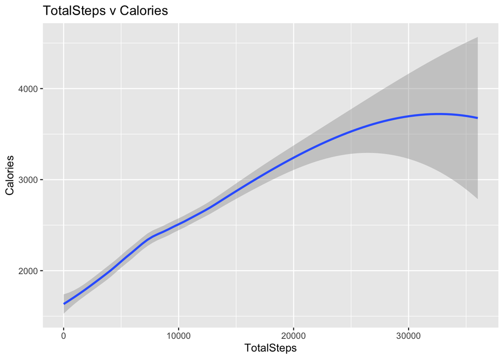

Here we see a positive relationship between the number of total steps and calories burned, more steps lead to more activity which in turn causes the user to burn more calories.

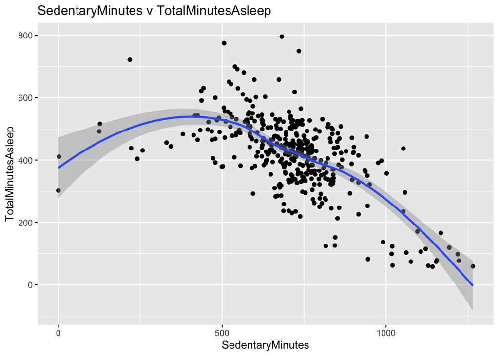

As SedentaryMinutes increased, we saw a decrease in TotalMinutesAsleep, this shows that the less active throughout the day the users are the less sleep they get.

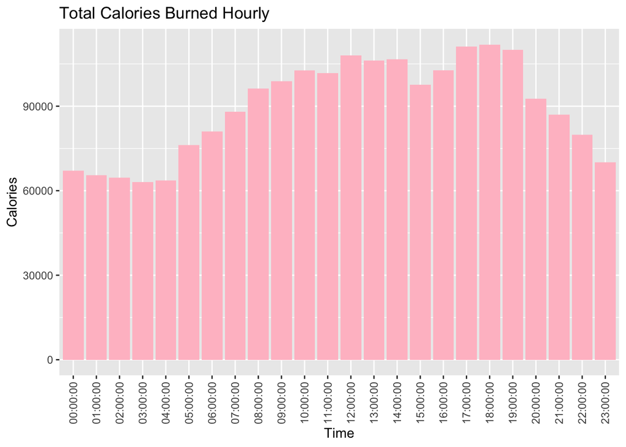

```r
ggplot(data = hourlyActivity,aes(x=Time,y=Calories))+
  geom_histogram(stat = 'identity',fill='pink') + theme(axis.text.x = element_text(angle = 90, vjust = 0.5, hjust=1)) + labs(title = "Total Calories Burned Hourly")
```

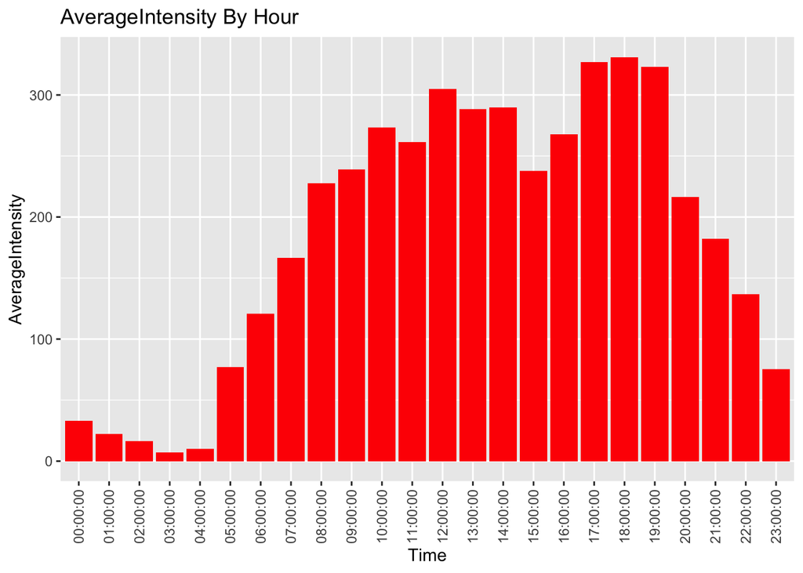

```r
ggplot(data = hourlyActivity,aes(x=Time,y=AverageIntensity))+
  geom_histogram(stat = 'identity',fill='red') + theme(axis.text.x = element_text(angle = 90, vjust = 0.5, hjust=1))+labs(title = "AverageIntensity By Hour")
```

In both plots 17:00-19:00 hold the highest values, this signifies that during these hours the users are the most physically active as they have the highest average intensity and most calories lost.

#Summary and Recommendations

Through the data we are able to get a picture of what type of people use fitness tracker devices, working women who find time later in the day to engage in light physical activity. However, there are quite a few limitations on this data, there is some missing data for an ID, 4057192912, which could affect the analysis. Based off what we have there are many things that we can include in Bellabeat products to increrase our presence in the global smart device market